# Лабораторная работа № 6

Мандатное разграничение прав в Linux

Мальянц Виктория Кареновна

1132246740@rudn.ru

Российский университет дружбы народов

2026-04-16

# Цель работы

- Развить навыки администрирования ОС Linux. Получить первое практическое знакомство с технологией SELinux1. Проверить работу SELinux на практике совместно с веб-сервером Apache.

# Задание

- Развить навыки администрирования ОС Linux

# Выполнение лабораторной работы

## Развить навыки администрирования ОС Linux

- Вхожу в систему с полученными учётными данными и убеждаюсь, что SELinux работает в режиме enforcing политики targeted с помощью команд getenforce и sestatus (рис. 1).

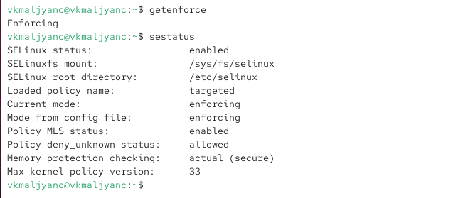

Применение команд getenforce и sestatus

## Развить навыки администрирования ОС Linux

- Обращаюсь с помощью браузера к веб-серверу, запущенному на моем компьютере, и убеждаюсь, что последний работает: service httpd status (рис. 2).

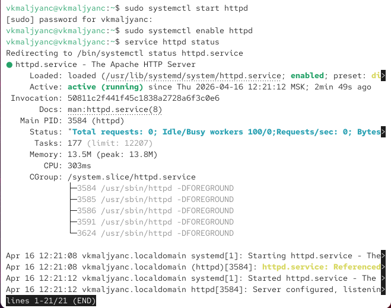

Применение команды service httpd status

## Развить навыки администрирования ОС Linux

- Нахожу веб-сервер Apache в списке процессов, определяю его контекст безопасности. Ипользую команду ps auxZ | grep httpd (рис. 3).

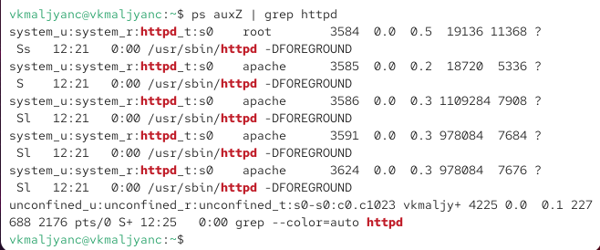

Применение команды ps auxZ | grep httpd

## Развить навыки администрирования ОС Linux

- Смотрю текущее состояние переключателей SELinux для Apache с помощью команды sestatus -b httpd (рис. 4).

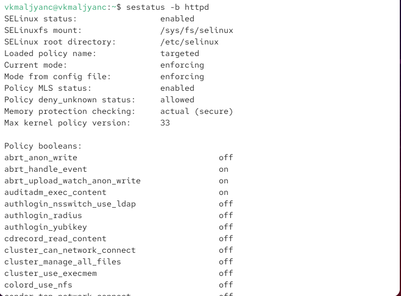

Применение команды sestatus -b httpd

## Развить навыки администрирования ОС Linux

- Смотрю статистику по политике с помощью команды seinfo, также определяю множество пользователей, ролей, типов (рис. 5).

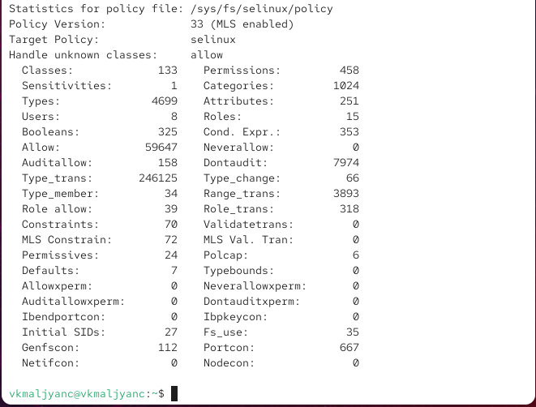

Применение команды seinfo

## Развить навыки администрирования ОС Linux

- Определяю тип файлов и поддиректорий, находящихся в директории /var/www, с помощью команды ls -lZ /var/www (рис. 6).

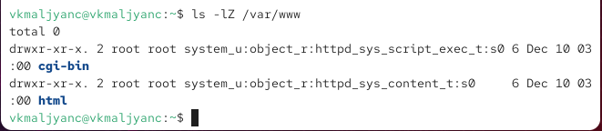

Применение команды ls -lZ /var/www

## Развить навыки администрирования ОС Linux

- Определяю тип файлов, находящихся в директории /var/www/html: ls -lZ /var/www/html (рис. 7).

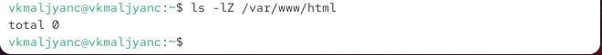

Применение команды ls -lZ /var/www/html

## Развить навыки администрирования ОС Linux

- Создаю от имени суперпользователя (так как в дистрибутиве после установки только ему разрешена запись в директорию) html-файл /var/www/html/test.html (рис. 8).

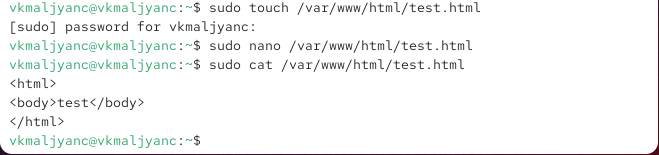

Создание html-файла

## Развить навыки администрирования ОС Linux

- Проверяю контекст созданного мною файла (рис. 9).

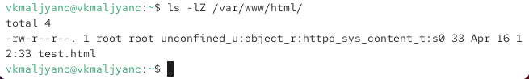

Проверка контекста созданного мною файла

## Развить навыки администрирования ОС Linux

- Обращаюсь к файлу через веб-сервер, введя в браузере адрес http://127.0.0.1/test.html. Убеждаюсь, что файл был успешно отображён (рис. 10).

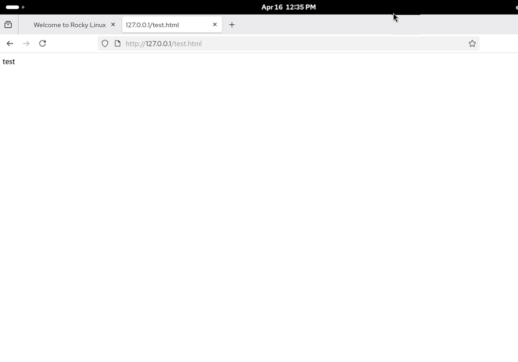

Ввод в браузере адреса http://127.0.0.1/test.html

## Развить навыки администрирования ОС Linux

- Изучаю справку man httpd selinux (рис. 11).

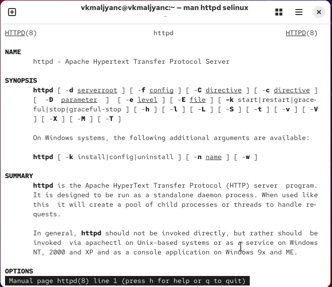

Изучение справки man httpd selinux

## Развить навыки администрирования ОС Linux

- Изменяю контекст файла /var/www/html/test.html с httpd_sys_content_t на любой другой, к которому процесс httpd не должен иметь доступа, например, на samba_share_t: chcon -t samba_share_t /var/www/html/test.html ls -Z /var/www/html/test.htm (рис. 12).

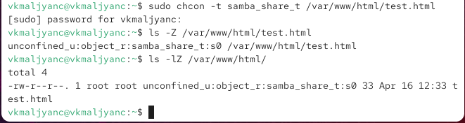

Изменение контекста файла

## Развить навыки администрирования ОС Linux

- Пробую ещё раз получить доступ к файлу через веб-сервер, введя в браузере адрес http://127.0.0.1/test.html. Получила сообщение об ошибке (рис. 13).

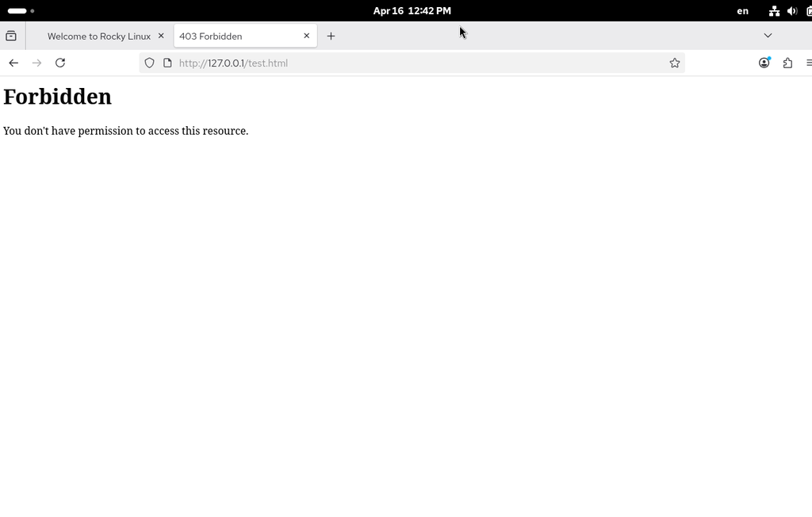

Ввод в браузере адреса http://127.0.0.1/test.html

## Развить навыки администрирования ОС Linux

- Просматриваю log-файлы веб-сервера Apache. Также просматриваю системный лог-файл: tail /var/log/messages. Также просматриваю файл /var/log/audit/audit.log (рис. 14).

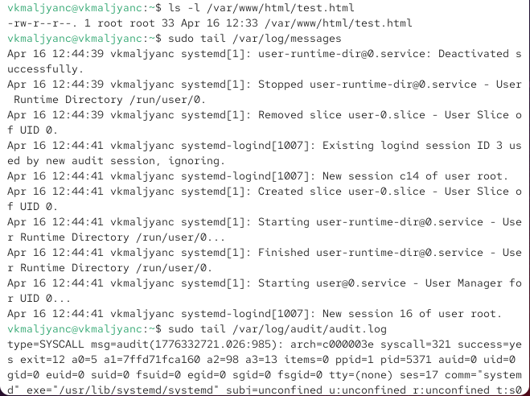

Просмотр файлов: ar/www/html/test.html, /var/log/messages, /var/log/audit/audit.log

## Развить навыки администрирования ОС Linux

- Пробую запустить веб-сервер Apache на прослушивание ТСР-порта 81 (рис. 15).

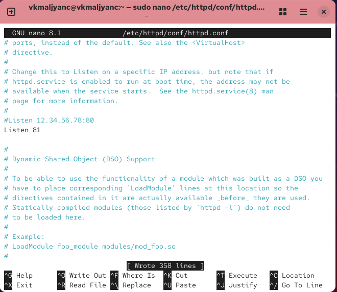

запуск веб-сервера Apache на прослушивание ТСР-порта 81

## Развить навыки администрирования ОС Linux

- Произошел сбой (рис. 16).

[figure not shown]

Сбой

## Развить навыки администрирования ОС Linux

- Просматриваю файл /var/log/http/error_log (рис. 18).

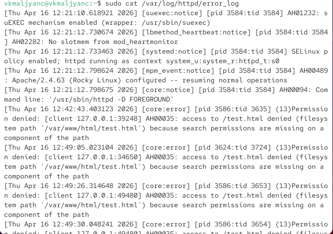

Просмотр файла /var/log/http/error_log

## Развить навыки администрирования ОС Linux

- Просматриваю файл var/log/http/access_log (рис. 19).

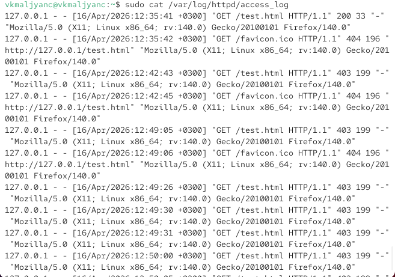

Просмотр файла var/log/http/access_log

## Развить навыки администрирования ОС Linux

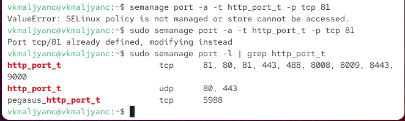

Появление 81 порта

## Развить навыки администрирования ОС Linux

- Пробую получить доступ к файлу через веб-сервер, введя в браузере адрес http://127.0.0.1:81/test.html (рис. 24).

[figure not shown]

Ввод в браузере адреса http://127.0.0.1:81/test.html

## Развить навыки администрирования ОС Linux

- Исправляю обратно конфигурационный файл apache, вернув Listen 80 (рис. 25).

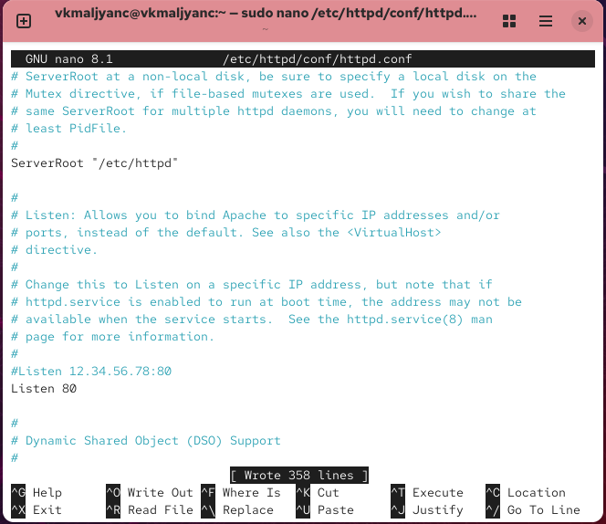

Исправление обратно конфигурационного файла apache

## Развить навыки администрирования ОС Linux

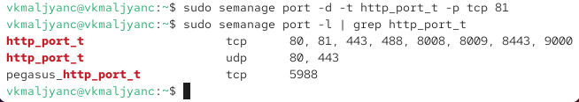

## Развить навыки администрирования ОС Linux

- Удаляю файл /var/www/html/test.html: rm /var/www/html/test.html (рис. 27).

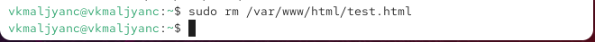

Применение команды rm /var/www/html/test.html

# Выводы

- Я развила навыки администрирования ОС Linux. Получила первое практическое знакомство с технологией SELinux1. Проверила работу SELinux на практике совместно с веб-сервером Apache.

# Спасибо за внимание